# Peer Graded Assignment: Prediction Assignment Writeup

Andrea Buda

03 maggio 2019

## Course Project : Practical Machine Learning

## Background

Using devices such as Jawbone Up, Nike FuelBand, and Fitbit it is now possible to collect a large amount of data about personal activity relatively inexpensively. These type of devices are part of the quantified self movement - a group of enthusiasts who take measurements about themselves regularly to improve their health, to find patterns in their behavior, or because they are tech geeks. One thing that people regularly do is quantify how much of a particular activity they do, but they rarely quantify how well they do it. In this project, your goal will be to use data from accelerometers on the belt, forearm, arm, and dumbell of 6 participants. They were asked to perform barbell lifts correctly and incorrectly in 5 different ways. More information is available from the website here: http://groupware.les.inf.puc-rio.br/har (see the section on the Weight Lifting Exercise Dataset).

## Exercise

### 1. Download the original files:

```r
temp            <- tempfile()
download.file("https://d396qusza40orc.cloudfront.net/predmachlearn/pml-training.csv",temp)
trainData        <- read.csv(temp, stringsAsFactors = F)

temp2           <- tempfile()
download.file("https://d396qusza40orc.cloudfront.net/predmachlearn/pml-testing.csv",temp2)
testData         <- read.csv(temp2, stringsAsFactors = F)
```

### 2. Removing columns that contains NA values

```r
TrainColClean   <- which(colSums(is.na(trainData) | trainData=="")>0.9*dim(trainData)[1])
trainDataC      <- trainData[,-TrainColClean]

TestColClean    <- which(colSums(is.na(testData) | testData=="")>0.9*dim(testData)[1])
testDataC       <- testData[,-TestColClean]
```

### 3. Partioning the training set into training and testing datasets

```r
set.seed(12345)
inTrain         <- createDataPartition( y = trainDataC$classe, p = 0.75, list = F)
training        <- trainDataC[inTrain,]
testing         <- trainDataC[-inTrain,]
testing$classe  <- as.factor(testing$classe)

dim(training); dim(testing)
```

```
## [1] 14718    60
```

```
## [1] 4904   60
```

## Building model and cross validation

### 1. Modelling with regression tree (“rpart”)

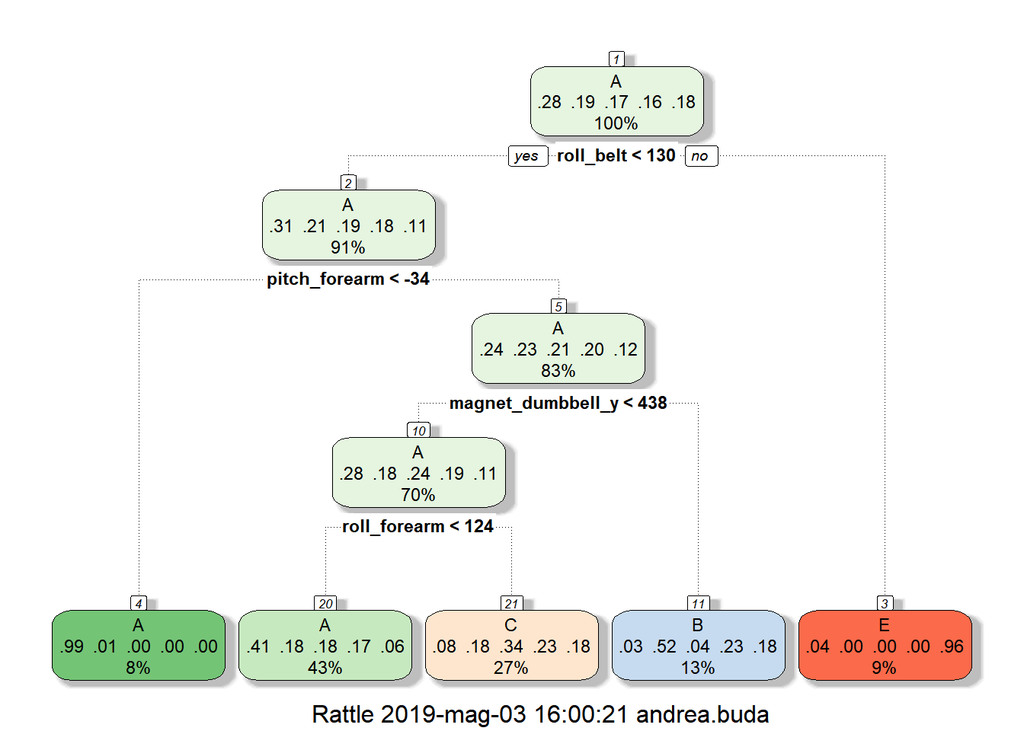

```r
trControl       <- trainControl(method="cv", number=5)
mod_tree        <- train(classe ~ ., method = "rpart", data = training[,-c(1:7)], trControl=trControl)

fancyRpartPlot(mod_tree$finalModel)
```

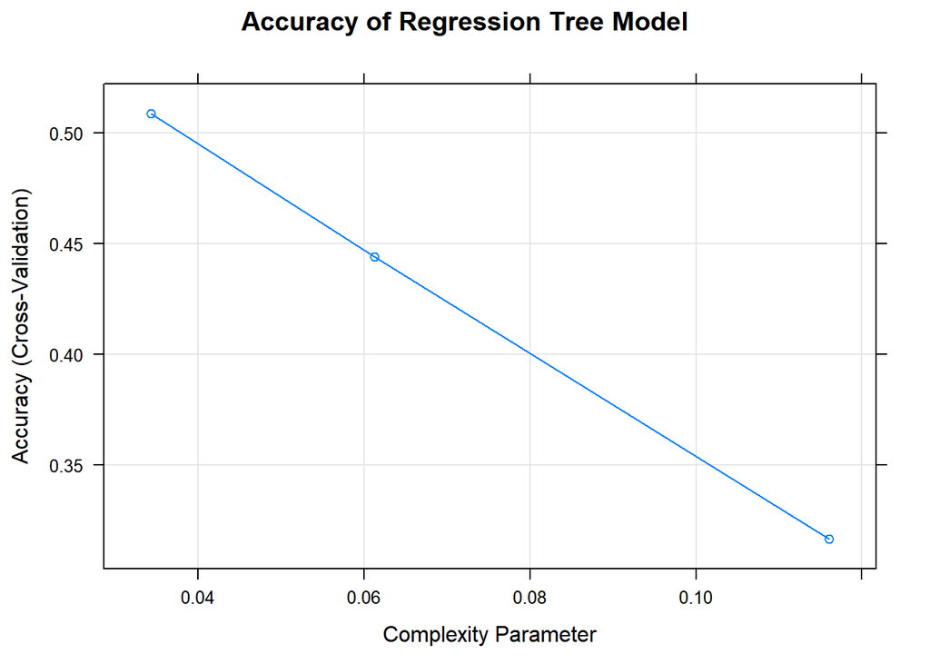

```r
ap              <- plot(mod_tree, main = "Accuracy of Regression Tree Model") # Accuracy plot
ap
```

```r
pred_tree       <- predict(mod_tree, testing)
confusionMatrix(testing$classe, pred_tree)
```

```
## Confusion Matrix and Statistics
##
##           Reference
## Prediction    A    B    C    D    E
##          A 1252   30   90    0   23
##          B  396  317  236    0    0
##          C  434   24  397    0    0
##          D  343  151  310    0    0
##          E  114  132  229    0  426
##
## Overall Statistics
##
##                Accuracy : 0.4878
##                  95% CI : (0.4737, 0.5019)
##     No Information Rate : 0.5177
##     P-Value [Acc > NIR] : 1
##
##                   Kappa : 0.3306
##
##  Mcnemar's Test P-Value : NA
##
## Statistics by Class:
##
##                      Class: A Class: B Class: C Class: D Class: E
## Sensitivity            0.4931  0.48471  0.31458       NA  0.94878
## Specificity            0.9395  0.85129  0.87424   0.8361  0.89338
## Pos Pred Value         0.8975  0.33404  0.46433       NA  0.47281
## Neg Pred Value         0.6332  0.91479  0.78637       NA  0.99425
## Prevalence             0.5177  0.13336  0.25734   0.0000  0.09156
## Detection Rate         0.2553  0.06464  0.08095   0.0000  0.08687
## Detection Prevalence   0.2845  0.19352  0.17435   0.1639  0.18373
## Balanced Accuracy      0.7163  0.66800  0.59441       NA  0.92108
```

### 2. Modelling with Stochastic Gradient Boosting (“gbm”)

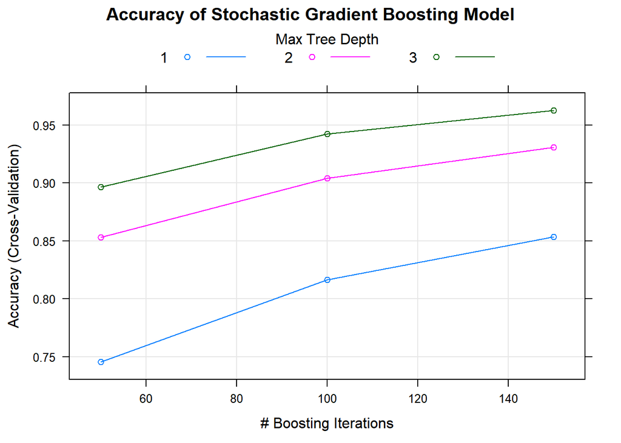

```r
mod_gbm         <- train(classe ~ . , data = training[,-c(1:7)], method="gbm", verbose=F , trControl=trControl)
ap              <- plot(mod_gbm, main = "Accuracy of Stochastic Gradient Boosting Model") # Accuracy plot
ap
```

```r
pred_gbm        <- predict(mod_gbm, testing)
confusionMatrix(testing$classe, pred_gbm)
```

```
## Confusion Matrix and Statistics
##
##           Reference
## Prediction    A    B    C    D    E
##          A 1376   15    1    3    0
##          B   20  899   28    2    0
##          C    0   20  820   15    0
##          D    2    3   36  757    6
##          E    0    8   10   10  873
##
## Overall Statistics
##
##                Accuracy : 0.9635
##                  95% CI : (0.9579, 0.9686)
##     No Information Rate : 0.2851
##     P-Value [Acc > NIR] : < 2.2e-16
##
##                   Kappa : 0.9538
##
##  Mcnemar's Test P-Value : NA
##
## Statistics by Class:
##
##                      Class: A Class: B Class: C Class: D Class: E
## Sensitivity            0.9843   0.9513   0.9162   0.9619   0.9932
## Specificity            0.9946   0.9874   0.9913   0.9886   0.9930
## Pos Pred Value         0.9864   0.9473   0.9591   0.9415   0.9689
## Neg Pred Value         0.9937   0.9884   0.9815   0.9927   0.9985
## Prevalence             0.2851   0.1927   0.1825   0.1605   0.1792
## Detection Rate         0.2806   0.1833   0.1672   0.1544   0.1780
## Detection Prevalence   0.2845   0.1935   0.1743   0.1639   0.1837
## Balanced Accuracy      0.9894   0.9693   0.9537   0.9752   0.9931
```

### 3. Modelling with Random Forest (“rf”)

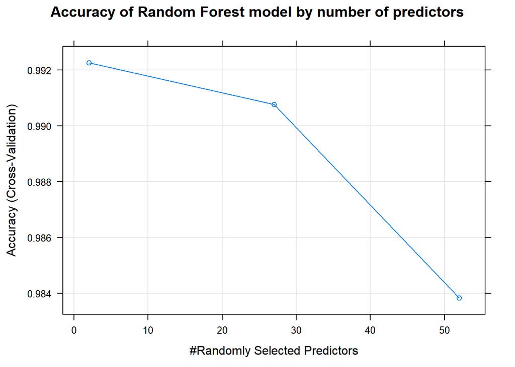

```r
mod_rf <- train(classe ~ . , data = training[,-c(1:7)], method = "rf", verbose = F, trControl=trControl)
plot(mod_rf, main = "Accuracy of Random Forest model by number of predictors") # Accuracy plot
```

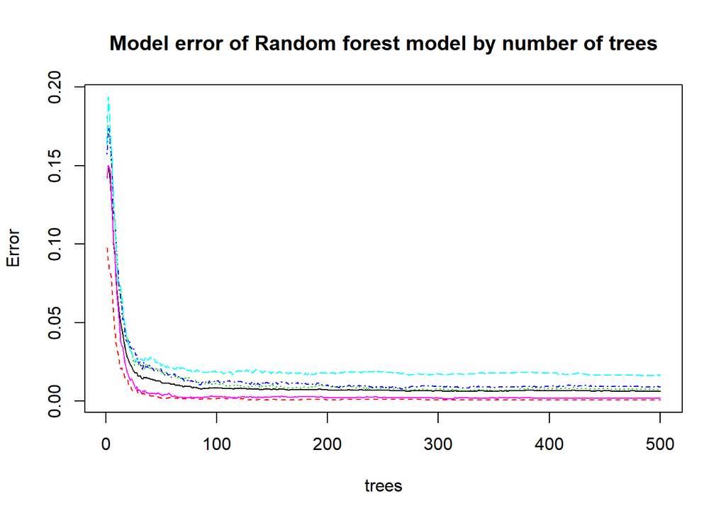

```r
plot(mod_rf$finalModel, main = "Model error of Random forest model by number of trees") #Error plot
```

```r
# Compute the variable importance
varImp(mod_rf)
```

```
## rf variable importance
##
##   only 20 most important variables shown (out of 52)
##
##                   Overall
## roll_belt          100.00
## yaw_belt            78.79
## magnet_dumbbell_z   64.18
## pitch_belt          60.68
## pitch_forearm       60.06
## magnet_dumbbell_y   59.26
## roll_forearm        50.99
## magnet_dumbbell_x   50.24
## magnet_belt_y       43.84
## accel_dumbbell_y    43.76
## accel_belt_z        43.55
## roll_dumbbell       41.82
## magnet_belt_z       41.66
## roll_arm            37.39
## accel_dumbbell_z    34.52
## accel_forearm_x     32.78
## gyros_dumbbell_y    31.29
## accel_dumbbell_x    28.13
## gyros_belt_z        27.94
## magnet_arm_x        27.18
```

```r
pred_rf <- predict(mod_rf, testing)
confusionMatrix(testing$classe, pred_rf)
```

```
## Confusion Matrix and Statistics
##
##           Reference
## Prediction    A    B    C    D    E
##          A 1395    0    0    0    0
##          B    1  946    2    0    0
##          C    0    6  849    0    0
##          D    0    0   15  784    5
##          E    0    0    1    0  900
##
## Overall Statistics
##
##                Accuracy : 0.9939
##                  95% CI : (0.9913, 0.9959)
##     No Information Rate : 0.2847
##     P-Value [Acc > NIR] : < 2.2e-16
##
##                   Kappa : 0.9923
##
##  Mcnemar's Test P-Value : NA
##
## Statistics by Class:
##
##                      Class: A Class: B Class: C Class: D Class: E
## Sensitivity            0.9993   0.9937   0.9792   1.0000   0.9945
## Specificity            1.0000   0.9992   0.9985   0.9951   0.9997
## Pos Pred Value         1.0000   0.9968   0.9930   0.9751   0.9989
## Neg Pred Value         0.9997   0.9985   0.9956   1.0000   0.9988
## Prevalence             0.2847   0.1941   0.1768   0.1599   0.1845
## Detection Rate         0.2845   0.1929   0.1731   0.1599   0.1835
## Detection Prevalence   0.2845   0.1935   0.1743   0.1639   0.1837
## Balanced Accuracy      0.9996   0.9965   0.9889   0.9976   0.9971
```

## Conclusion

The results show that the Random Forest Model has the highest accuracy in cross validation. Therefore, we will use the random forest model for predicting test samples.

```r
t <-as.data.frame(cbind(rbind("Regression Tree", "Gradient Boosting", "Random Forest"),
      rbind(round(confusionMatrix(testing$classe, pred_tree)$overall[1],3)*100,
            round(confusionMatrix(testing$classe, pred_gbm)$overall[1],3)*100,
            round(confusionMatrix(testing$classe, pred_rf)$overall[1],3)*100)))

names(t) <- c("Model", "Accuracy")
t
```

```
##               Model Accuracy
## 1   Regression Tree     48.8
## 2 Gradient Boosting     96.3
## 3     Random Forest     99.4
```

```r
predTest <- predict(mod_rf, testData)
as.data.frame(predTest)
```

```
##    predTest
## 1         B
## 2         A
## 3         B
## 4         A
## 5         A
## 6         E
## 7         D
## 8         B
## 9         A
## 10        A
## 11        B
## 12        C
## 13        B
## 14        A
## 15        E
## 16        E
## 17        A
## 18        B
## 19        B
## 20        B
```